# Final Project

Roxanne Felig

4/16/2021

## Final Project Introduction

This project explores the relationship between self-objectification (the extent to which an individual takes an observer’s perspective of their own body), body awareness (awareness and ability to recognize internal bodily states), and intuitive eating (an eating style based on physiological hunger and satiety cues). Previous research has found relationships between self-objectification and body awareness, self-objectification and intuitive eating, and body awareness and intuitive eating, but to my knowledge no research explores the relationship between the three constructs.

I have collected correlational data from both undergraduates in the SONA participant pool which will test a mediational model, whereby self-objectification reduces intuitive eating, mediated by reduced body awareness. For this project, I will be cleaning the data set, reverse scoring items, creating summary scores, and will begin to explore the data.

## Data Cleaning

First order of business is to rename variables so that I can easily use them. The self-objectification variables are named appropriately (e.g., SO1-SO14), but the other variable names are not intuitively named.The re-coding scheme will be as follows:

Q18-Q25 are the body shame items and will be re-named BS1-BS8. BS 5 and 7 will then be reverse-scored before computing average scores.

Q27_1 through Q27_19 **with the exception of Q27_11 which is an attention check** will be re-coded as BAQ1-BAQ18 (measure of body awareness). Items will be reverse coded and sub-scale averages as well as grand average will be computed.

Q28_1 through Q28_24 **with the exception of Q28_13 which is an attention check** will be coded as eat_1-eat_23 (measure of intuitive eating). Reverse coded items will be scored and an average score will be computed.

Q34 will become age

Q36-sex (coded as 1=female, 2=male, 3= neither describes me)

Q38-gender (coded as 1=woman, 2=,man, 3=trans-woman, 4= trans-man, 5=nb, 6= self-describe, 7= prefer not to say)

Q48- race.

Using setnames, I will recode the body shame and body awareness items first. Below is the corresponding code.

```r
setnames(ie.data, old = c('Q18','Q19','Q20', 'Q21', 'Q22', 'Q23', 'Q24', 'Q25', 'Q27_1','Q27_2','Q27_3', 'Q27_4', 'Q27_5', 'Q27_6','Q27_7', 'Q27_8', 'Q27_9', 'Q27_10', 'Q27_11', 'Q27_12','Q27_13', 'Q27_14', 'Q27_15', 'Q27_16', 'Q27_17', 'Q27_18', 'Q27_19'),
         new =c('BS1','BS2','BS3', 'BS4','BS5', 'BS6', 'BS7', 'BS8','BAQ1','BAQ2','BAQ3', 'BAQ4','BAQ5', 'BAQ6', 'BAQ7', 'BAQ8', 'BAQ9','BAQ10', 'Attn_check2', 'BAQ11', 'BAQ12', 'BAQ13', 'BAQ14', 'BAQ15','BAQ16', 'BAQ17', 'BAQ18'))
```

Next, I am re-naming the intuitive eating items.

```r
setnames(ie.data, old = c('Q28_1','Q28_2','Q28_3','Q28_4','Q28_5','Q28_6','Q28_7','Q28_8',
'Q28_9', 'Q28_10','Q28_11','Q28_12','Q28_14','Q28_15','Q28_16','Q28_17','Q28_18','Q28_19',
'Q28_20','Q28_21','Q28_22','Q28_23','Q28_24'),
         new =c('eat_1','eat_2','eat_3','eat_4','eat_5','eat_6','eat_7','eat_8','eat_9','eat_10','eat_11','eat_12','eat_13','eat_14','eat_15', 'eat_16', 'eat_17','eat_18','eat_19','eat_20','eat_21','eat_22','eat_23'))
```

Lastly, I am re-naming the demographic variables that will be most important for my analyses.

```r
setnames(ie.data, old = c('Q34','Q36','Q38','Q48'),
         new =c('age','sex','gender','race'))
```

Now I am creating two sets of reverse scored items, grouped by whether or not they are on a scale of 1-5 or 1-7. After grouping them, I created a new data frame including the reverse scored items.

```r
reversed1<- c("BS5","BS7","BAQ10")
reversed2<-c("eat_1","eat_2","eat_3", "eat_7","eat_8","eat_9","eat_10")

ie_reverse<-ie.data %>%
  mutate(
    across(all_of(reversed1),
           ~ recode(.x, "7" = 1, "6" = 2, "5" = 3, "4" = 4, "3" = 5,"2"= 6, "1" = 7),
           .names = "{.col}r")
  ) %>%
  mutate(
    across(all_of(reversed2),
           ~ recode(.x, "5" = 1, "4" = 2, "3" = 3, "2" = 4, "1" = 5),
           .names = "{.col}r")
  )
```

Using the relocate function, I am moving all of the attention check variables to the ends of the data set so that I can more easily summarize across variables.

```r
ie_clean<-ie_reverse %>%
  relocate(Attn1, .after="Q54") %>%
  relocate(Attn_check2, .after="Attn1") %>%
  relocate(Q28_13, .after= "Attn_check2")
```

While I was able to use c_across to quickly compute a mean score of self-objectification, I realized that in the previous step, the newly reverse coded items were also placed at the end of the data set, making it challenging to use c_across to create average scores.

```r
ie_full<-ie_clean %>%
  rowwise() %>%
  mutate(
    .id=Q54,
    self_obj=mean(c_across(SO1:SO14), na.rm=TRUE),
    bod_shame=mean(c(BS1, BS2,BS3,BS4,BS5r,BS6, BS7r,BS8), na.rm = TRUE),
    bod_aware=mean(c(BAQ1,BAQ2,BAQ3,BAQ4,BAQ5,BAQ6,BAQ7,BAQ8,BAQ9,BAQ10r,
    BAQ11,BAQ12,BAQ13,BAQ14,BAQ15,BAQ16,BAQ17,BAQ18),na.rm = TRUE),
    eating=mean(c(eat_1r,eat_2r,eat_3r,eat_4,eat_5,eat_6,eat_7r,eat_8r,eat_9r,
    eat_10r, eat_11,eat_12, eat_13, eat_14, eat_15, eat_16, eat_17, eat_18, eat_19,
    eat_20, eat_21,eat_22, eat_23),na.rm = TRUE),
    .before = everything()
  )
```

## Data Exploring

Now that I have my average scores of interest, I am creating a subset of data using the select function to simplify my data set. I am plotting each variable to see how the distributions look.

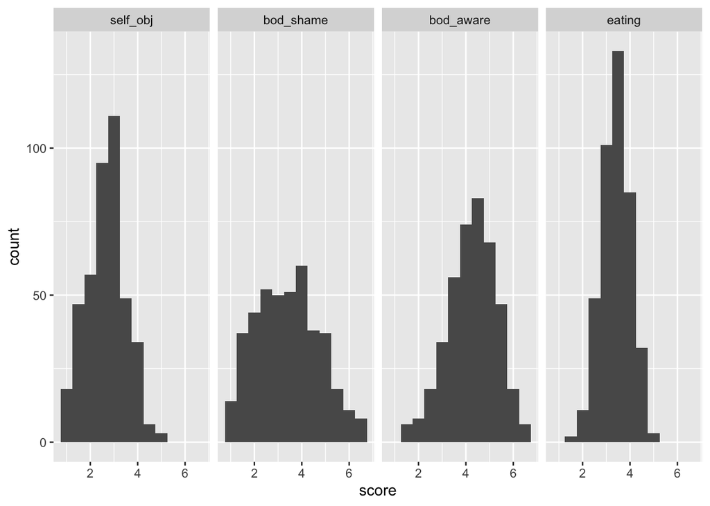

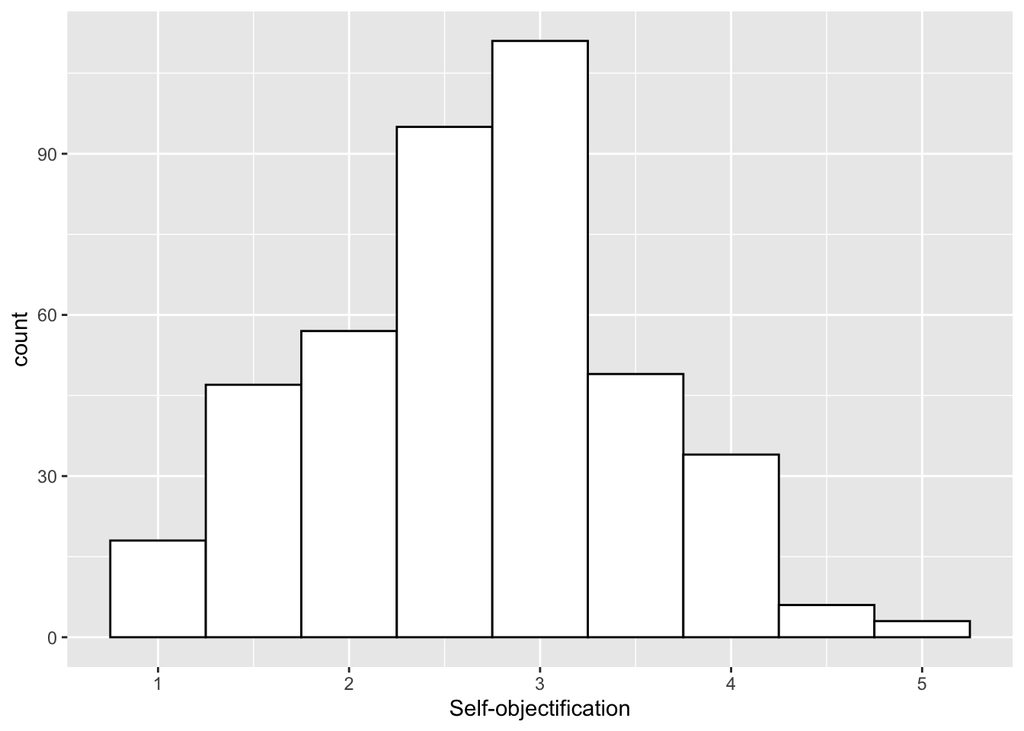

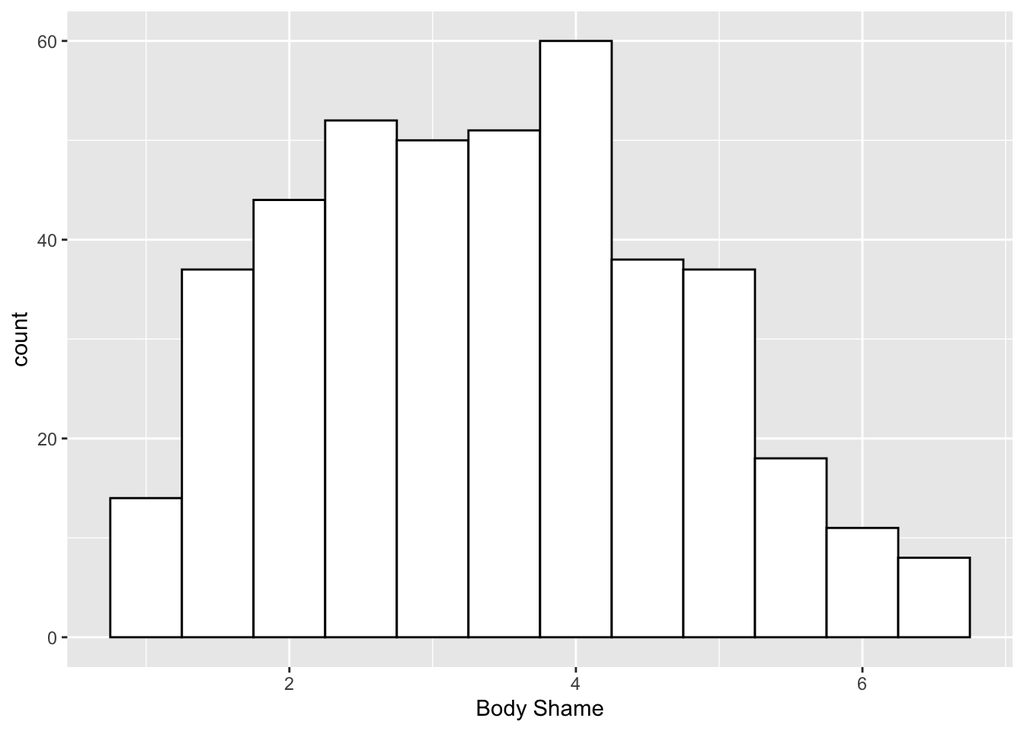

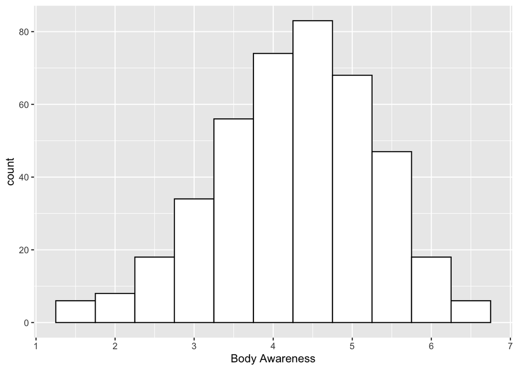

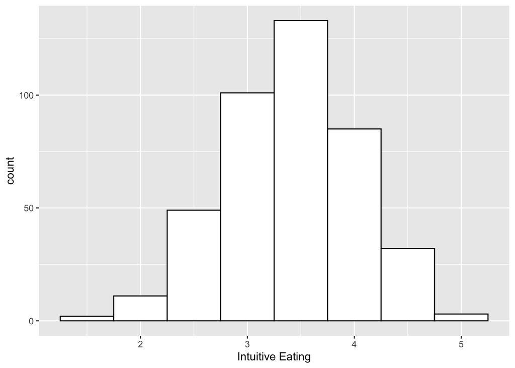

The individual plots are easier to interpret than the side-by-side, given that the side-by-side puts them all on a scale of 1-7 when some are scored from 1-5. Body awareness and intuitive eating appear to be normally distributed, with self-objectification and body shame looking less normal, but not horribly skewed.

## Correlations

Now using my subsetted data, I am going to look at the correlations of all variables of interest.

```
##           self_obj bod_shame bod_aware eating
## self_obj      1.00      0.71      0.09  -0.36
## bod_shame     0.71      1.00      0.07  -0.49
## bod_aware     0.09      0.07      1.00   0.17
## eating       -0.36     -0.49      0.17   1.00
##
## n
##           self_obj bod_shame bod_aware eating
## self_obj       420       420       418    416
## bod_shame      420       420       418    416
## bod_aware      418       418       418    416
## eating         416       416       416    416
##
## P
##           self_obj bod_shame bod_aware eating
## self_obj           0.0000    0.0654    0.0000
## bod_shame 0.0000             0.1434    0.0000
## bod_aware 0.0654   0.1434              0.0004
## eating    0.0000   0.0000    0.0004
```

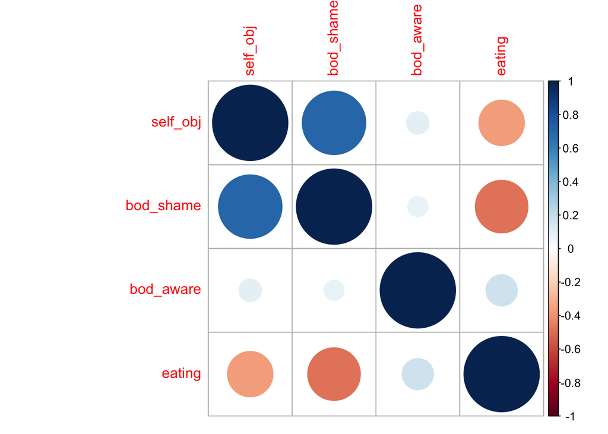

Here we see the correlation coefficients, followed by the number of observations, and then the p values. Surprisingly, and contrary to my hypothesis, body awareness is not significantly correlated with self-objectification or body shame. However, these correlations are using the entire sample of participants, with no filters or screening.

To explore how men and women differ, I need to identify my variable of ‘gender’ as a factor and label the levels.

Now I’m going to only filter women who passed all three attention checks, and repeat the correlation analysis.

```
##           self_obj bod_shame bod_aware eating
## self_obj      1.00      0.71      0.06  -0.44
## bod_shame     0.71      1.00      0.03  -0.54
## bod_aware     0.06      0.03      1.00   0.20
## eating       -0.44     -0.54      0.20   1.00
##
## n= 262
##
##
## P
##           self_obj bod_shame bod_aware eating
## self_obj           0.0000    0.3272    0.0000
## bod_shame 0.0000             0.6821    0.0000
## bod_aware 0.3272   0.6821              0.0012
## eating    0.0000   0.0000    0.0012
```

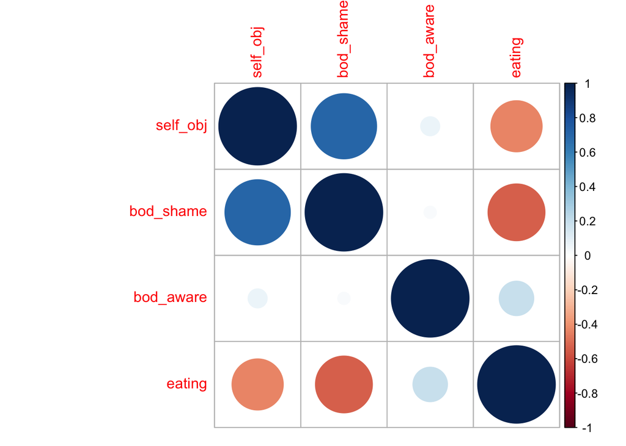

Well, this is surprising. In a sample of 262 women, body awareness is not significantly correlated with self-objectification or body shame. Self-objectification is negatively correlated with intuitive eating, as expected, and body awareness and intuitive eating are positively correlated, as expected.

Let’s so how the men’s data look.

```
##           self_obj bod_shame bod_aware eating
## self_obj      1.00      0.68      0.09  -0.34
## bod_shame     0.68      1.00      0.18  -0.40
## bod_aware     0.09      0.18      1.00   0.07
## eating       -0.34     -0.40      0.07   1.00
##
## n= 103
##
##
## P
##           self_obj bod_shame bod_aware eating
## self_obj           0.0000    0.3533    0.0004
## bod_shame 0.0000             0.0654    0.0000
## bod_aware 0.3533   0.0654              0.4922
## eating    0.0004   0.0000    0.4922
```

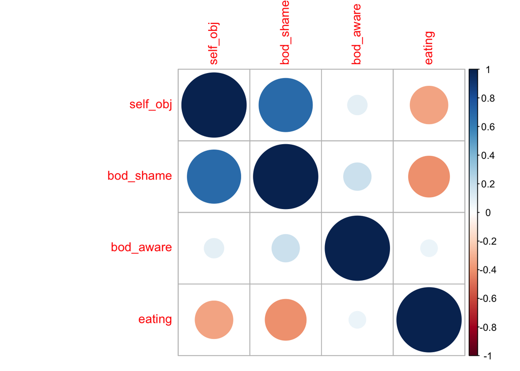

Here we see a similar pattern whereby body awareness is not significantly correlated with either self-objectification or intuitive eating.

## Conclusion

Contrary to previous findings, I found no support for a relationship between self-reported level of body awareness and self-objectification. As such, I don’t believe my mediation model will work. This finding is surprising given the existing research demonstrating reduces body awareness as a consequence of self-objectification, but it’s possible that this construct is difficult to self-report.